# Practice Visual Priming

Dave Yachabach

4/21/2021

## Practice Statistical Analysis for Visual Priming Experiment

This document describes a statistical analysis of simulated data. The data simulates the performance of airline crews flying approach scenarios in a Level D 737 flight simulator. For a description of the experiment see *Rethinking Runway Safety from the Bottom Up*. See the codebook for a description of variables and tables.

## Data Description

The operational data for this practice analysis is in a practice data file. The available files are:

- *PD_4-22-2021.csv*.

The simulated Roster data is in a Roster file. The available files are:

- *Roster_4-21-2021*

### Independence of RunIDs

The following graphs indicate that RunIDs were evenly distributed throughout a simulator session. In other words, RL-NI was just as likely to occur on the 6th run as on the 15th run.

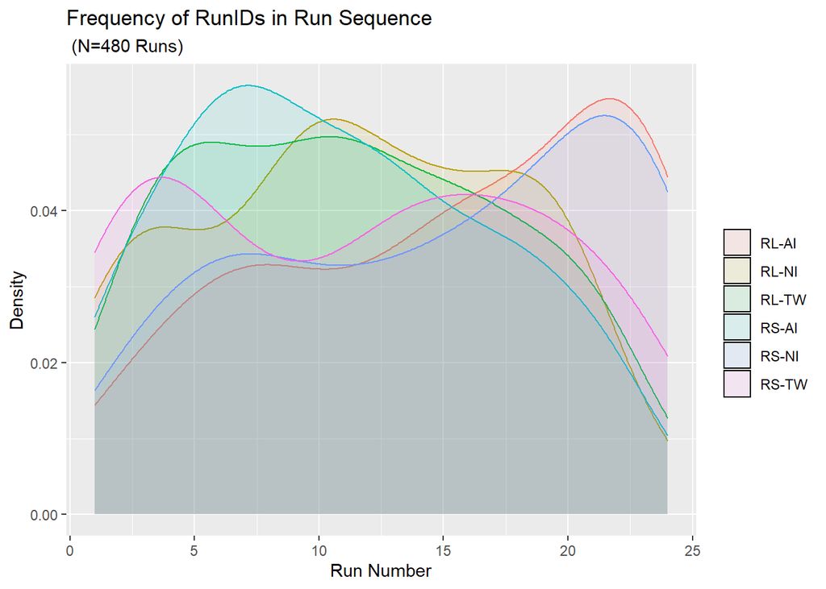

### Landing Accuracy

Starting with landing accuracy, we will show the frequency distribution of the population separted by treatment and control. It’s a little easier to see the decrease in variance between treatment and control with a density distribution.

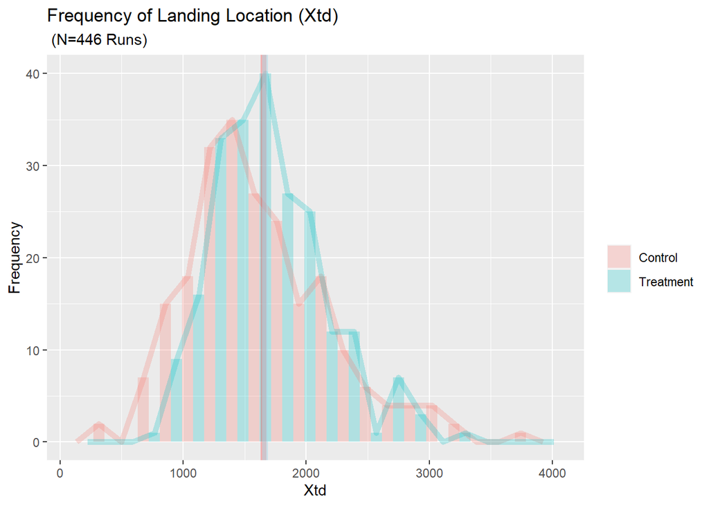

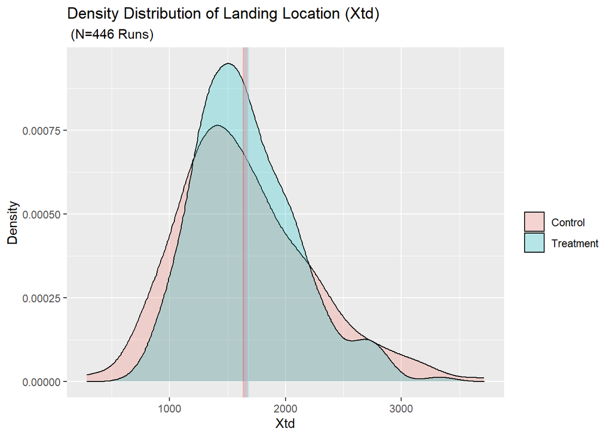

### Go Around Likelihood

The following graph shows the difference in the go-around rate between treatment and control. The difference is small. The treatment group went around 18, while the control went around 16.

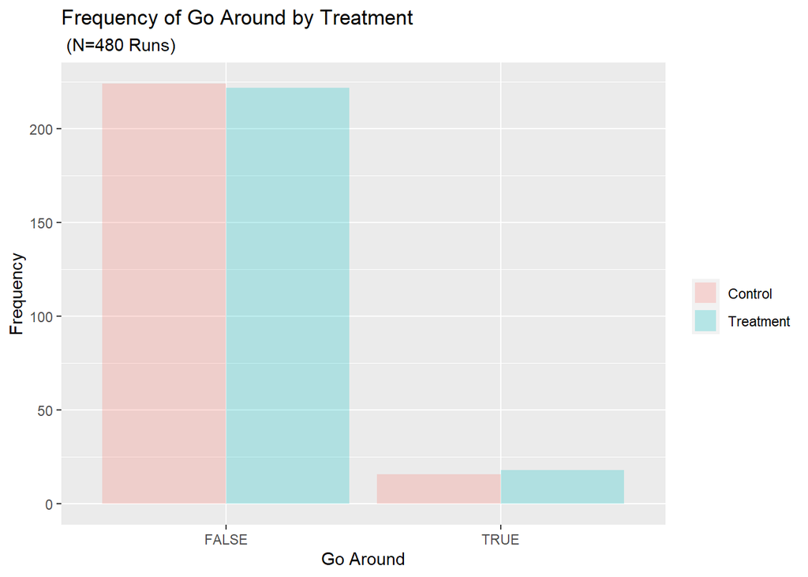